# R Notebook

# The following project was completed to determine the likelihood of a home run every instance of a ball in play given a number of metrics. I chose to use a Random Forest model as it creates a ‘forest’ of decision trees where the output is the class selecting the most trees which removes bias within the data. Random Forest is one of the strongest predictive models that one can create and given the amount of data within the data set, I deemed it too great for that of a single decsion tree to handle.

# Below are the packages I used to create this model.

```r
require(dplyr)
require(randomForest)
require(ggplot2)
require(ROCR)
require(corrplot)
require(pROC)
library(dplyr)
library(randomForest)
library(ggplot2)
library(ROCR)
library(corrplot)
library(pROC)
```

# I first uploaded the data set in RStudio and checked its summary and structure to gain a better understanding of the data. I noticed that there were 98 NA values within the data set. This consitituted 0.1% of the data set so I deemed it prudent to omit them. I noticed two character attributes that I wanted to obtain a better understanding of the data within them. I decided to see the unique values within each and noticed they could definitely play a factor in predicting a home run.

```r
url <- "https://raw.githubusercontent.com/Chrisboatto/Likelihood-of-a-Homerun/main/Balls%20in%20play.csv"
```

```r
BallsInPlay <- read.csv(url)
```

```r
str(BallsInPlay)
```

```
'data.frame':   61413 obs. of  40 variables:
 $ X                        : int  1 2 3 4 5 6 7 8 9 10 ...
 $ GAME_ID                  : int  310 375 17 541 17 1175 569 446 30 462 ...
 $ DAY_OR_NIGHT             : chr  "N" "N" "N" "N" ...
 $ TEMPERATURE              : int  66 76 71 72 71 70 81 69 65 71 ...
 $ WEATHER                  : chr  "Cloudy" "Cloudy" "Clear" "Clear" ...
 $ WIND_SPEED               : int  8 8 10 6 10 6 3 7 10 8 ...
 $ WIND_DIRECTION           : chr  "Out To CF" "R To L" "Out To CF" "Out To CF" ...
 $ PLAY_ID                  : int  14861 18009 792 26000 793 57702 27306 21297 1380 22106 ...
 $ PITCHER_ID               : int  97 610 38 86 38 75 651 623 836 333 ...
 $ PITCHER_SIDE             : chr  "R" "L" "R" "R" ...
 $ BATTER_ID                : int  4 8 8 8 20 30 35 37 37 37 ...
 $ BATTER_SIDE              : chr  "R" "R" "R" "R" ...
 $ STADIUM_ID               : int  1 1 1 1 1 1 1 1 1 1 ...
 $ INNING                   : int  6 8 4 2 4 3 4 5 2 7 ...
```

[output cut: 26 more lines]

```r
summary(BallsInPlay)
```

```
       X            GAME_ID     DAY_OR_NIGHT        TEMPERATURE       WEATHER
 Min.   :    1   Min.   :   1   Length:61413       Min.   : 32.00   Length:61413
 1st Qu.:15354   1st Qu.: 321   Class :character   1st Qu.: 68.00   Class :character
 Median :30707   Median : 638   Mode  :character   Median : 73.00   Mode  :character
 Mean   :30707   Mean   : 633                      Mean   : 73.16
 3rd Qu.:46060   3rd Qu.: 946                      3rd Qu.: 81.00
 Max.   :61413   Max.   :1248                      Max.   :102.00

   WIND_SPEED     WIND_DIRECTION        PLAY_ID        PITCHER_ID    PITCHER_SIDE
 Min.   : 0.000   Length:61413       Min.   :    1   Min.   :  1.0   Length:61413
 1st Qu.: 4.000   Class :character   1st Qu.:15354   1st Qu.:179.0   Class :character
 Median : 7.000   Mode  :character   Median :30707   Median :382.0   Mode  :character
 Mean   : 7.042                      Mean   :30707   Mean   :389.6
 3rd Qu.:10.000                      3rd Qu.:46060   3rd Qu.:586.0
 Max.   :25.000                      Max.   :61413   Max.   :848.0

   BATTER_ID     BATTER_SIDE          STADIUM_ID        INNING       INNING_HALF
 Min.   :  1.0   Length:61413       Min.   : 1.00   Min.   : 1.000   Length:61413
 1st Qu.:183.0   Class :character   1st Qu.: 8.00   1st Qu.: 3.000   Class :character
 Median :381.0   Mode  :character   Median :16.00   Median : 5.000   Mode  :character
 Mean   :393.4                      Mean   :16.43   Mean   : 4.886
 3rd Qu.:587.0                      3rd Qu.:25.00   3rd Qu.: 7.000
 Max.   :843.0                      Max.   :32.00   Max.   :16.000

      OUTS            BALLS          STRIKES       PITCH_TYPE        PITCH_VELOCITY
 Min.   :0.0000   Min.   :0.000   Min.   :0.000   Length:61413       Min.   : 32.97
 1st Qu.:0.0000   1st Qu.:0.000   1st Qu.:0.000   Class :character   1st Qu.: 84.70
 Median :1.0000   Median :1.000   Median :1.000   Mode  :character   Median : 89.74
 Mean   :0.9628   Mean   :1.093   Mean   :1.103                      Mean   : 88.76
 3rd Qu.:2.0000   3rd Qu.:2.000   3rd Qu.:2.000                      3rd Qu.: 93.52
 Max.   :2.0000   Max.   :3.000   Max.   :2.000                      Max.   :101.99

 HORIZONTAL_BREAK  INDUCED_VERTICAL_BREAK  RELEASE_SIDE     RELEASE_HEIGHT
 Min.   :-27.358   Min.   :-25.907        Min.   :-4.5116   Min.   :1.048
 1st Qu.:-11.148   1st Qu.:  2.292        1st Qu.:-2.0694   1st Qu.:5.632
 Median : -2.543   Median :  8.894        Median :-1.4369   Median :5.916
 Mean   : -1.552   Mean   :  7.569        Mean   :-0.7172   Mean   :5.877
 3rd Qu.:  7.328   3rd Qu.: 14.925        3rd Qu.: 1.2371   3rd Qu.:6.203
 Max.   : 55.700   Max.   : 46.057        Max.   : 4.4699   Max.   :7.567

```

[output cut: 16 more lines]

```
 HORIZONTAL_APPROACH_ANGLE VERTICAL_APPROACH_ANGLE PITCH_RESULT       EVENT_RESULT
 Min.   :-7.1321           Min.   :-27.9678        Length:61413       Length:61413
 1st Qu.:-0.5944           1st Qu.: -7.4518        Class :character   Class :character
 Median : 0.6888           Median : -6.2681        Mode  :character   Mode  :character
 Mean   : 0.6290           Mean   : -6.4744
 3rd Qu.: 2.0050           3rd Qu.: -5.3037
 Max.   : 7.4695           Max.   : -0.2186

 SINGLE_YES_OR_NO DOUBLE_YES_OR_NO  TRIPLE_YES_OR_NO   HOME_RUN_YES_OR_NO
 Min.   :0.0000   Min.   :0.00000   Min.   :0.000000   Min.   :0.00000
 1st Qu.:0.0000   1st Qu.:0.00000   1st Qu.:0.000000   1st Qu.:0.00000
 Median :0.0000   Median :0.00000   Median :0.000000   Median :0.00000
 Mean   :0.2049   Mean   :0.06549   Mean   :0.005357   Mean   :0.04975
 3rd Qu.:0.0000   3rd Qu.:0.00000   3rd Qu.:0.000000   3rd Qu.:0.00000
 Max.   :1.0000   Max.   :1.00000   Max.   :1.000000   Max.   :1.00000
```

```r
sum(is.na(BallsInPlay))
```

```
[1] 98
```

```r
BallsInPlay <- na.omit(BallsInPlay)
```

```r
sum(is.na(BallsInPlay))
```

```
[1] 0
```

```r
unique(BallsInPlay$WEATHER)
```

```
 [1] "Cloudy"        "Clear"         "Sunny"         "Partly Cloudy" "Overcast"
 [6] "Drizzle"       "Rain"          "Dome"          "Roof Closed"   "Snow"
```

```r
unique(BallsInPlay$WIND_DIRECTION)
```

```
 [1] "Out To CF"  "R To L"     "Out To LF"  "Out To RF"  "In From RF" "Varies"
 [7] "In From CF" "Calm"       "In From LF" "L To R"     "None"
```

# I created the lolipop box plots below to gain a better understanding of the interquartile ranges amongst the numeric metrics and where the outliers are. Notice the two outliers amongst the break attributes. Both those outliers were on one single pitch, a fastball. This does not make sense as fastball are supposed to be almost as straight as an arrow. Having a break on your fastball over 40" is not normal and should be seen as an outlier. I used these box plots as a means to subset out any outliers within the data. I removed the two large breaks and and velocity seen under 65mph. Even though the first interquartile range starts at 84.7mph, I deemed it prudent to keep any pitches over 65mph within the data set simply because some pitchers have curveballs that are in the low 70’s. Therefore, setting the subset to 65mph would ensure all curveballs were included. Any pitch recorded below that could be deemed a ‘lob’ from a position player.

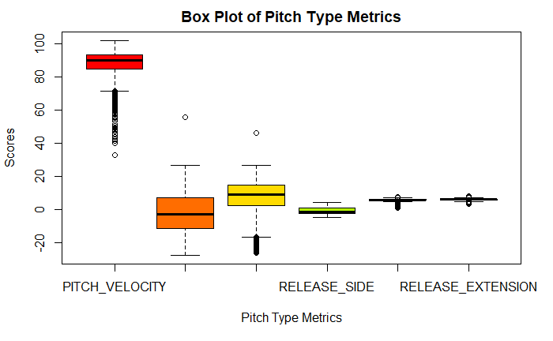

```r
boxplot(BallsInPlay[20:25], col = rainbow(14), main = "Box Plot of Pitch Type Metrics", xlab = "Pitch Type Metrics", ylab = "Scores")
```

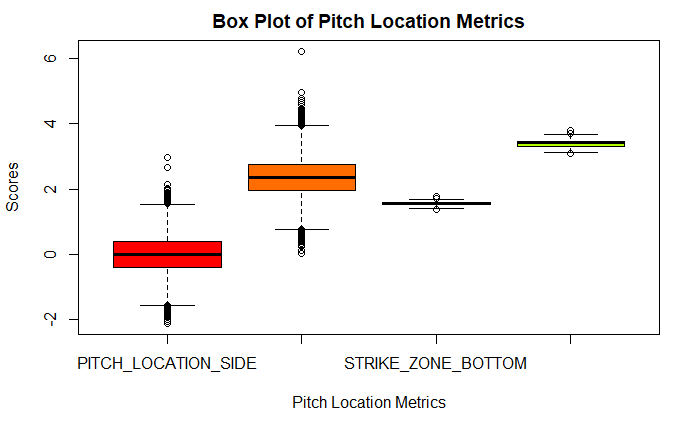

```r
boxplot(BallsInPlay[26:29], col = rainbow(14), main = "Box Plot of Pitch Location Metrics", xlab = "Pitch Location Metrics", ylab = "Scores")
```

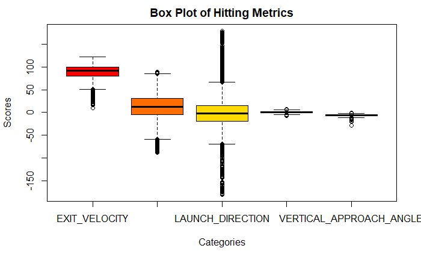

```r
boxplot(BallsInPlay[30:34], col = rainbow(14), main = "Box Plot of Hitting Metrics", xlab = "Categories", ylab = "Scores")
```

```r
BallsInPlay <- filter(BallsInPlay, PITCH_VELOCITY > 65)
BallsInPlay <- filter(BallsInPlay, HORIZONTAL_BREAK < 40)
BallsInPlay <- filter(BallsInPlay, INDUCED_VERTICAL_BREAK < 40)
```

# Below is a correlation plot depicting how well each metric is correlated to all others within the data set. The deeper the blue, the more positively correlated the metrics are and the deeper the red, the more negatively correlated.

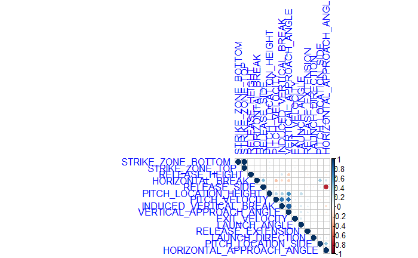

```r
BallsInPlay_Cor <- cor(BallsInPlay[20:34])
corrplot(BallsInPlay_Cor, type = "upper", order = 'hclust', tl.col = "blue")
```

# I then trained the data on an 80:20 train to test ratio based on random samples to avoid any bias. Making the ratios split at random is a key factor as I wanted to remove as much bias as possible throughout my entire model creation. I wanted to produce the most fair and unbiased model possible that way I can ensure the highest level of accuracy that way I know my model is correct.

```r
set.seed(49838)

train <- sample(nrow(BallsInPlay), 0.80*nrow(BallsInPlay), replace = FALSE)

TrainSet <- BallsInPlay[train,]
TestSet <- BallsInPlay[-train,]
```

# I then created a base model using the ‘HOME_RUN_YES_OR_NO’ variable as my dependent and using all others as my independents. This base model will allow me to gain an understanding of what metrics have the highest importance within the model. The importance metric shows how much of an influence the attribute has on the output. If the metric is too high then it could lead to domination thus resulting in an overfit. As you can see below, ‘EVENT_RESULT’ had the most influence on the dependent variable by a wide margin which is understandable as it shows results of the ball in play much like that of the binary event attributes do. This therefore shold be removed as it is redundant.

```r
baseModel <- randomForest(HOME_RUN_YES_OR_NO ~., data = TrainSet, importance = TRUE, ntrees = 50)
```

```
The response has five or fewer unique values.  Are you sure you want to do regression?
```

```r
baseImp <- importance(baseModel)
baseImp
```

```
                              %IncMSE IncNodePurity
X                           2.7320394  1.174493e+00
GAME_ID                     1.6173046  1.075286e+00
DAY_OR_NIGHT                0.5423704  7.664622e-02
TEMPERATURE                 3.8628281  1.275216e+00
WEATHER                     3.3758679  3.525400e-01
WIND_SPEED                  3.8173723  5.771819e-01
WIND_DIRECTION              2.4319115  5.120678e-01
PLAY_ID                     1.6869548  1.102509e+00
PITCHER_ID                  2.3077577  9.762363e-01
PITCHER_SIDE                2.2644514  4.799229e-02
BATTER_ID                  -0.3300185  1.319165e+00
BATTER_SIDE                 4.3111957  1.378616e+00
STADIUM_ID                  2.8525809  5.679066e-01
INNING                      0.7708357  5.149824e-01
INNING_HALF                 0.1070203  7.181232e-02
OUTS                        8.0115504  2.321572e+00
BALLS                      -0.2297726  2.724325e-01
STRIKES                     1.9967077  1.856844e-01
PITCH_TYPE                  5.9285826  3.945828e-01
PITCH_VELOCITY              3.2578666  1.576967e+00
HORIZONTAL_BREAK            7.4820179  1.227269e+00
INDUCED_VERTICAL_BREAK      7.3683253  1.382915e+00
RELEASE_SIDE                6.8849656  1.121749e+00
RELEASE_HEIGHT              2.4088444  1.126859e+00
RELEASE_EXTENSION           1.8121842  1.229567e+00
PITCH_LOCATION_SIDE         7.5805227  3.223223e+00
PITCH_LOCATION_HEIGHT       5.7636791  5.227219e+00
STRIKE_ZONE_BOTTOM          0.4468919  4.994305e-01
STRIKE_ZONE_TOP             2.1216938  5.595360e-01
EXIT_VELOCITY              13.2234705  2.783730e+02
LAUNCH_ANGLE               20.8950833  3.132646e+02
LAUNCH_DIRECTION           12.2365912  1.285220e+01
HORIZONTAL_APPROACH_ANGLE   7.2814306  1.449038e+00
VERTICAL_APPROACH_ANGLE     5.4605171  1.353097e+00
PITCH_RESULT                0.0000000  0.000000e+00
EVENT_RESULT              127.0968553  1.336773e+03
SINGLE_YES_OR_NO           19.4620914  2.728379e+02
DOUBLE_YES_OR_NO           14.0099400  2.144700e+01
TRIPLE_YES_OR_NO           13.6428458  2.577857e+01
```

[figure not shown]

```r
baseImp <- as.data.frame(baseImp)
ggplot(baseImp, aes(IncNodePurity, row.names(baseImp))) +
  geom_bar(stat = "identity", width = 0.1, fill = "black") +
  geom_point(shape = 21, size = 3, colour = "black", fill = "red", stroke = 2) +
  labs(title = "Home Run Importance", x = "Importance", y = "Variable")
```